# Chapter 14 - Semantic preference

Bodo Winter

8/24/2018

## Introduction

This is the analysis for Chapter 14, which is the first to combine the modality norms with a corpus, COCA (Davies, 2008-). Part I looks at overall “modality affinity” using cosine similarity in adjective-noun pairs. Part II looks at correlations between an adjective’s modality and a noun’s modality.

We begin by loading in the data and libraries.

```r
## Libraries:

library(stringr)
library(lme4)
library(MuMIn)
library(car)
library(tidyverse)

## Load data:

lyn <- read_csv('../raw-data/modality_lynott_connell_2009.csv')
noun <- read_csv('../raw-data/modality_lynott_connell_2013.csv')
COCA <- read_csv('../raw-data/COCA_adj_noun.csv')
```

Some more preliminaries:

```r
## Vector of modality names:

mymods <- c('Visual', 'Haptic', 'Auditory',
            'Gustatory', 'Olfactory')

## Vector of column names:

mymods_names <- str_c(mymods, 'StrengthMean')

## Load plotting functions:

source('../functions/emptyplot.R')
source('../functions/plot_density.R')
source('../functions/cosine_sim.R')

## Create unique adjective-noun pair identifier:

COCA <- mutate(COCA,
    ID = str_c(Word, Noun, sep = ':'))
```

Check type and token counts:

```r
nrow(COCA)
```

```
## [1] 149387
```

```r
sum(COCA$Freq)
```

```
## [1] 1023851
```

Make a column that contains info about whether the noun is also in Lynott and Connell (2013) and check how many there are.

```r
## Make a column for whether nouns that are also in L&C 2013:

COCA <- mutate(COCA,
    LC2013 = ifelse(Noun %in% noun$Word, 'match', 'no_match'))

## Check type and token counts:

nrow(filter(COCA, LC2013 == 'match'))
```

```
## [1] 13685
```

```r
sum(filter(COCA, LC2013 == 'match')$Freq)
```

```
## [1] 183533
```

Create a superset that contains all possible adjective-noun combinations, to be compared with those that are actually attested.

```r
## Create super-set of all possible adjective-noun combinations:

adj <- tibble(Word = rep(lyn$Word, each = nrow(noun)),
              Noun = rep(noun$Word, times = nrow(lyn))) %>%
  mutate(ID = str_c(Word, Noun, sep = ':'))

## Create a column for whether it is attested or not:

adj <- mutate(adj,
              Attested = ifelse(ID %in% COCA$ID, 'yes', 'no'))
```

How many are attested and how many are unattested?

```r
## Counts and percentages of attested versus unatteted:

nrow(filter(adj, Attested == 'yes'))
```

```
## [1] 13685
```

```r
nrow(filter(adj, Attested == 'no'))
```

```
## [1] 155515
```

```r
nrow(filter(adj, Attested == 'yes')) / nrow(adj)
```

```
## [1] 0.08088061
```

```r
nrow(filter(adj, Attested == 'no')) / nrow(adj)
```

```
## [1] 0.9191194
```

Add the perceptual strengths of the adjective and the noun to this dataset.

```r
## Add adjective perceptual strengths:

colnames(lyn)[str_detect(colnames(lyn), 'StrengthMean')] <- str_c('Adj',
    colnames(lyn)[str_detect(colnames(lyn), 'StrengthMean')])
adj <- left_join(adj, lyn)
## Add noun perceptual strengths:

colnames(noun)[str_detect(colnames(noun), 'StrengthMean')] <- str_c('Noun',
    colnames(noun)[str_detect(colnames(noun), 'StrengthMean')])
adj <- left_join(adj, noun, by = c('Noun' = 'Word'))
```

And the token frequency of the adjective-noun pair that’s attested in COCA for those that are attested (others will be NA).

```r
## Add COCA frequency to adj:

adj$Freq <- COCA[match(adj$ID, COCA$ID), ]$Freq

## Compute log frequency:

adj <- mutate(adj, LogFreq = log10(Freq))
```

This will be the main dataset with which we work from now.

## Computing cosines

Here, we will compute the cosines and save this into a file:

```r
## Create empty cosine column to fill with modality fit:

cosines <- rep(NA, nrow(adj))

## Separate matrices into adjectives and nouns:

adj_vecs <- adj[, grep('Adj(.)+StrengthMean', colnames(adj))]
noun_vecs <- adj[, grep('Noun(.)+StrengthMean', colnames(adj))]
adj_vecs <- as.matrix(adj_vecs)
noun_vecs <- as.matrix(noun_vecs)

## Loop through pairs and compute cosines:

for (i in 1:nrow(adj)) {
    cosines[i] <- cosine_sim(adj_vecs[i, ], noun_vecs[i, ])
    # if (i %% 1000 == 0) {cat(paste(i, '\n'))}
}

## Put back into data frame:

adj$Cosine <- cosines

## Write to file:
write_csv(adj, '../processed-data/combinations_with_cosines.csv')
```

Let’s check a few exemplary values.

```r
## Extract relevant data frames:

abrasive_contact <- filter(adj,
                      Word == 'abrasive', Noun == 'contact')
sweet_music <- filter(adj,
                      Word == 'sweet', Noun == 'music')
sweet_taste <- filter(adj,
                      Word == 'sweet', Noun == 'taste')

## This adjective, perceptual strength values:

sweet_music[, grep('Adj(.)+StrengthMean', colnames(adj))] %>%
  print(width = Inf)
```

```
## # A tibble: 1 x 5
##   AdjVisualStrengthMean AdjHapticStrengthMean AdjAuditoryStrengthMean
##                   <dbl>                 <dbl>                   <dbl>
## 1                  2.19                 0.571                    1.19
##   AdjGustatoryStrengthMean AdjOlfactoryStrengthMean
##                      <dbl>                    <dbl>
## 1                     4.86                     3.90
```

```r
## The two nouns, perceptual strength values:

sweet_music[, grep('Noun(.)+StrengthMean', colnames(adj))] %>%
  print(width = Inf)
```

```
## # A tibble: 1 x 5
##   NounVisualStrengthMean NounAuditoryStrengthMean NounHapticStrengthMean
##                    <dbl>                    <dbl>                  <dbl>
## 1                   2.24                     4.94                   1.24
##   NounGustatoryStrengthMean NounOlfactoryStrengthMean
##                       <dbl>                     <dbl>
## 1                         0                    0.0588
```

```r
sweet_taste[, grep('Noun(.)+StrengthMean', colnames(adj))] %>%
  print(width = Inf)
```

```
## # A tibble: 1 x 5
##   NounVisualStrengthMean NounAuditoryStrengthMean NounHapticStrengthMean
##                    <dbl>                    <dbl>                  <dbl>
## 1                   1.25                    0.235                   1.65
##   NounGustatoryStrengthMean NounOlfactoryStrengthMean
##                       <dbl>                     <dbl>
## 1                         5                      2.35
```

```r
## What are the cosines?
sweet_music$Cosine
```

```
## [1] 0.2513931
```

```r
sweet_taste$Cosine
```

```
## [1] 0.9630103
```

```r
## Look at "abrasive contact":

abrasive_contact[, grep('Adj(.)+StrengthMean', colnames(adj))] %>%
  print(width = Inf)
```

```
## # A tibble: 1 x 5
##   AdjVisualStrengthMean AdjHapticStrengthMean AdjAuditoryStrengthMean
##                   <dbl>                 <dbl>                   <dbl>
## 1                  2.89                  3.68                    1.68
##   AdjGustatoryStrengthMean AdjOlfactoryStrengthMean
##                      <dbl>                    <dbl>
## 1                    0.579                    0.579
```

```r
abrasive_contact[, grep('Noun(.)+StrengthMean', colnames(adj))] %>%
  print(width = Inf)
```

```
## # A tibble: 1 x 5
##   NounVisualStrengthMean NounAuditoryStrengthMean NounHapticStrengthMean
##                    <dbl>                    <dbl>                  <dbl>
## 1                   3.41                     2.53                   3.53
##   NounGustatoryStrengthMean NounOlfactoryStrengthMean
##                       <dbl>                     <dbl>
## 1                      1.06                      1.12
```

```r
abrasive_contact$Cosine
```

```
## [1] 0.9126385
```

## Analysis of cosines

How many data adjective-noun pairs are attested, compared to the unattesteds?

```r
## Get the counts:

att_count <- adj %>%
  group_by(Attested) %>%
  count()

## Check:

att_count
```

```
## # A tibble: 2 x 2
## # Groups:   Attested [2]
##   Attested      n
##   <chr>     <int>
## 1 no       155515
## 2 yes       13685
```

```r
## How many in total?

sum(att_count$n)
```

```
## [1] 169200
```

```r
## Percentage:

att_count[2, ]$n / sum(att_count$n)
```

```
## [1] 0.08088061
```

```r
## Compare cosines of unattested and attested combinations:

aggregate(Cosine ~ Attested, adj, mean)
```

```
##   Attested    Cosine
## 1       no 0.7611800
## 2      yes 0.8067239
```

```r
aggregate(Cosine ~ Attested, adj, sd)
```

```
##   Attested    Cosine
## 1       no 0.1857737
## 2      yes 0.1510421
```

```r
aggregate(Cosine ~ Attested, adj, median)
```

```
##   Attested    Cosine
## 1       no 0.8082731
## 2      yes 0.8363906
```

```r
## Perform Wilcox test:

wilcox.test(Cosine ~ Attested, adj)
```

```
##
##  Wilcoxon rank sum test with continuity correction
##
## data:  Cosine by Attested
## W = 931630000, p-value < 2.2e-16
## alternative hypothesis: true location shift is not equal to 0
```

Let’s make a plot of the distribution of cosines for attested versus unattested pairs:

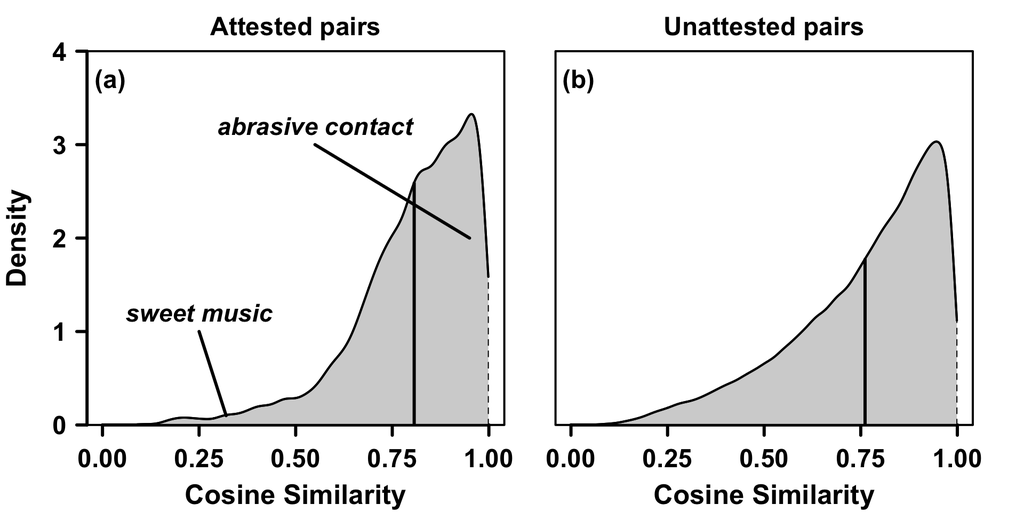

```r
## Make a plot of the exclusivity distributions:

quartz('', 11, 4)
par(mfrow = c(1,2),
    mai = c(0.25, 0.25, 0.25, 0.25),
    omi = c(0.6, 0.6, 0.25, 0.25))

# Plot 1:
plot(1, 1, type = 'n', xlim = c(0, 1), ylim = c(0, 4),
     yaxs = 'i', xlab = '', ylab = '', xaxt = 'n', yaxt = 'n')
plot_AB(xlim = c(0, 1),
        ylim = c(0, 4), AB = '(a)',
        xfactor = 0.02, yfactor = 0.08)
# Axes:
axis(side = 1, at = seq(0, 1, 0.25),
     lwd = 3, labels = FALSE)
axis(side = 1, at = seq(0, 1, 0.25),
     tick = FALSE, labels = TRUE,
     font = 2, line = 0.25, cex.axis = 1.5)
mtext(side = 1, line = 3.05, text = 'Cosine Similarity',
      cex = 1.6, font = 2)
axis(side = 2, at = seq(0, 5, 1),
     tick = TRUE, labels = TRUE,
     font = 2, cex.axis = 1.5, las = 2, lwd = 3)
mtext(side = 2, line = 2.8, text = 'Density',
      cex = 1.6, font = 2)
# Density etc.
plot_density(filter(adj, Attested == 'yes')$Cosine,
             mean = TRUE, this_color = 'lightgray')
box(lwd = 2)
mtext(side = 3, text = 'Attested pairs',
      font = 2, line = 0.6, cex = 1.5)
# plot words:
segments(x0 = 0.95, x1 = 0.55, y0 = 2, y1 = 3, lwd = 3)
text(x = 0.55, y = 3.20, labels = 'abrasive contact',
     font = 4, cex = 1.45)
segments(x0 = 0.32, x1 = 0.25, y0 = 0.1, y1 = 1, lwd = 3)
text(x = 0.25, y = 1.20, labels = 'sweet music',
     font = 4, cex = 1.45)

# Plot 2:
plot(1, 1, type = 'n', xlim = c(0, 1), ylim = c(0, 4), yaxs = 'i',
    xlab = '', ylab = '', xaxt = 'n', yaxt = 'n')
plot_AB(xlim = c(0, 1), ylim = c(0, 4), AB = '(b)',
    xfactor = 0.02, yfactor = 0.08)
# Axes:
axis(side = 1, at = seq(0, 1, 0.25),
     lwd = 3, labels = F)
axis(side = 1, at = seq(0, 1, 0.25),
     tick = FALSE, labels = TRUE,
     font = 2, line = 0.25, cex.axis = 1.5)
mtext(side = 1, line = 3.05, text = 'Cosine Similarity',
    cex = 1.6, font = 2)
# Density etc.
plot_density(filter(adj, Attested == 'no')$Cosine,
             mean = TRUE, this_color = 'lightgray')
box(lwd = 2)
mtext(side = 3, text = 'Unattested pairs',
      font = 2, line = 0.6, cex = 1.5)
```

## Cosine and frequency

Are words with higher cosines more frequent? We’ll answer this with a mixed model fitted on log frequencies.

```r
## Mixed model:

summary(cos_freq_lmer <- lmer(LogFreq ~ Cosine +
    (1 + Cosine|Word) + (1 + Cosine|Noun),
    filter(adj, Attested == 'yes'), REML = FALSE))
```

```
## Linear mixed model fit by maximum likelihood  ['lmerMod']
## Formula: LogFreq ~ Cosine + (1 + Cosine | Word) + (1 + Cosine | Noun)
##    Data: filter(adj, Attested == "yes")
##
##      AIC      BIC   logLik deviance df.resid
##  19859.0  19926.7  -9920.5  19841.0    13676
##
## Scaled residuals:
##     Min      1Q  Median      3Q     Max
## -2.4334 -0.6456 -0.2100  0.4491  7.4097
##
## Random effects:
##  Groups   Name        Variance Std.Dev. Corr
##  Word     (Intercept) 0.07782  0.2790
##           Cosine      0.08068  0.2840   -0.77
##  Noun     (Intercept) 0.06608  0.2571
##           Cosine      0.12472  0.3532   -0.83
##  Residual             0.22841  0.4779
## Number of obs: 13685, groups:  Word, 396; Noun, 359
##
## Fixed effects:
##             Estimate Std. Error t value
## (Intercept)  0.15880    0.04231   3.753
## Cosine       0.03963    0.05186   0.764
##
## Correlation of Fixed Effects:
##        (Intr)
## Cosine -0.939
```

```r
## Null model:

summary(cos_freq_lmer_null <- lmer(LogFreq ~ 1 +
    (1 + Cosine|Word) + (1 + Cosine|Noun),
    filter(adj, Attested == 'yes'), REML = FALSE))
```

```
## Linear mixed model fit by maximum likelihood  ['lmerMod']
## Formula: LogFreq ~ 1 + (1 + Cosine | Word) + (1 + Cosine | Noun)
##    Data: filter(adj, Attested == "yes")
##
##      AIC      BIC   logLik deviance df.resid
##  19857.5  19917.7  -9920.7  19841.5    13677
##
## Scaled residuals:
##     Min      1Q  Median      3Q     Max
## -2.4276 -0.6453 -0.2086  0.4487  7.4069
##
## Random effects:
##  Groups   Name        Variance Std.Dev. Corr
##  Word     (Intercept) 0.07591  0.2755
##           Cosine      0.08120  0.2850   -0.76
##  Noun     (Intercept) 0.06525  0.2554
##           Cosine      0.12698  0.3563   -0.83
##  Residual             0.22840  0.4779
## Number of obs: 13685, groups:  Word, 396; Noun, 359
##
## Fixed effects:
##             Estimate Std. Error t value
## (Intercept)  0.18909    0.01451   13.03
```

```r
## Likelihood ratio test:

anova(cos_freq_lmer_null,
    cos_freq_lmer, test = 'Chisq')
```

```
## Data: filter(adj, Attested == "yes")
## Models:
## cos_freq_lmer_null: LogFreq ~ 1 + (1 + Cosine | Word) + (1 + Cosine | Noun)
## cos_freq_lmer: LogFreq ~ Cosine + (1 + Cosine | Word) + (1 + Cosine | Noun)
##                    Df   AIC   BIC  logLik deviance  Chisq Chi Df
## cos_freq_lmer_null  8 19858 19918 -9920.7    19842
## cos_freq_lmer       9 19859 19927 -9920.5    19841 0.4609      1
##                    Pr(>Chisq)
## cos_freq_lmer_null
## cos_freq_lmer          0.4972
```

```r
## Check R-squared:

r.squaredGLMM(cos_freq_lmer)
```

```
##          R2m          R2c
## 0.0001234348 0.2131014328
```

Compare with Poisson models.

```r
## Mixed model:

summary(cos_freq_pois <- glmer(Freq ~ Cosine +
    (1 + Cosine|Word) + (1 + Cosine|Noun),
    filter(adj, Attested == 'yes'), family = 'poisson'))
```

```
## Generalized linear mixed model fit by maximum likelihood (Laplace
##   Approximation) [glmerMod]
##  Family: poisson  ( log )
## Formula: Freq ~ Cosine + (1 + Cosine | Word) + (1 + Cosine | Noun)
##    Data: filter(adj, Attested == "yes")
##
##       AIC       BIC    logLik  deviance  df.resid
##  419655.8  419716.0 -209819.9  419639.8     13677
##
## Scaled residuals:
##    Min     1Q Median     3Q    Max
## -52.47  -1.73  -0.42   0.93 750.25
##
## Random effects:
##  Groups Name        Variance Std.Dev. Corr
##  Word   (Intercept) 14.37    3.790
##         Cosine      20.47    4.524    -0.96
##  Noun   (Intercept) 41.72    6.459
##         Cosine      54.59    7.389    -0.99
## Number of obs: 13685, groups:  Word, 396; Noun, 359
##
## Fixed effects:
##             Estimate Std. Error z value Pr(>|z|)
## (Intercept)    1.440      0.403   3.572 0.000354 ***
## Cosine        -1.868      0.467  -4.000 6.33e-05 ***
## ---
## Signif. codes:  0 '***' 0.001 '**' 0.01 '*' 0.05 '.' 0.1 ' ' 1
##
## Correlation of Fixed Effects:
##        (Intr)
## Cosine -0.978
## convergence code: 0
## Model failed to converge with max|grad| = 0.00199186 (tol = 0.001, component 1)
```

```r
save(cos_freq_pois, file = '../models/cos_freq_pois.mdl')

## Null model:

summary(cos_freq_pois_null <- glmer(Freq ~ 1 +
    (1 + Cosine|Word) + (1 + Cosine|Noun),
    filter(adj, Attested == 'yes'), family = 'poisson'))
```

```
## Generalized linear mixed model fit by maximum likelihood (Laplace
##   Approximation) [glmerMod]
##  Family: poisson  ( log )
## Formula: Freq ~ 1 + (1 + Cosine | Word) + (1 + Cosine | Noun)
##    Data: filter(adj, Attested == "yes")
##
##       AIC       BIC    logLik  deviance  df.resid
##  419668.8  419721.5 -209827.4  419654.8     13678
##
## Scaled residuals:
##    Min     1Q Median     3Q    Max
## -52.47  -1.73  -0.42   0.93 754.23
##
## Random effects:
##  Groups Name        Variance Std.Dev. Corr
##  Word   (Intercept) 14.65    3.828
##         Cosine      20.75    4.555    -0.96
##  Noun   (Intercept) 43.72    6.612
##         Cosine      56.91    7.544    -0.99
## Number of obs: 13685, groups:  Word, 396; Noun, 359
##
## Fixed effects:
##             Estimate Std. Error z value Pr(>|z|)
## (Intercept) -0.14375    0.08448  -1.702   0.0888 .
## ---
## Signif. codes:  0 '***' 0.001 '**' 0.01 '*' 0.05 '.' 0.1 ' ' 1
```

```r
save(cos_freq_pois_null, file = '../models/cos_freq_pois_null.mdl')

## Likelihood ratio test:

anova(cos_freq_pois_null,
    cos_freq_pois, test = 'Chisq')
```

```
## Data: filter(adj, Attested == "yes")
## Models:
## cos_freq_pois_null: Freq ~ 1 + (1 + Cosine | Word) + (1 + Cosine | Noun)
## cos_freq_pois: Freq ~ Cosine + (1 + Cosine | Word) + (1 + Cosine | Noun)
##                    Df    AIC    BIC  logLik deviance  Chisq Chi Df
## cos_freq_pois_null  7 419669 419721 -209827   419655
## cos_freq_pois       8 419656 419716 -209820   419640 15.045      1
##                    Pr(>Chisq)
## cos_freq_pois_null
## cos_freq_pois        0.000105 ***
## ---
## Signif. codes:  0 '***' 0.001 '**' 0.01 '*' 0.05 '.' 0.1 ' ' 1
```

```r
## Check R-squared:

r.squaredGLMM(cos_freq_pois)
```

```
## The result is correct only if all data used by the model has not changed since model was fitted.
```

```
##          R2m          R2c
## 0.0003342119 0.1995847942
```

Let’s make a graph of this:

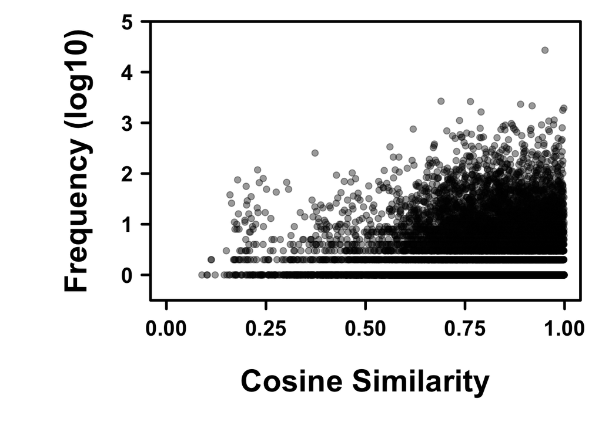

```r
## Cosine by frequency graph:

quartz('', 9, 6)
par(mai = c(1.5, 1.75, 0.25, 0.25))
plot(1, 1, xlim = c(0, 1), ylim = c(-0.5, 5),
     type = 'n', yaxs = 'i', xlab = '', ylab ='',
     xaxt = 'n', yaxt = 'n', bty = 'n')
axis(side = 1, at = seq(0, 1, 0.25),
     lwd = 3, labels = FALSE)
axis(side = 1, at = seq(0, 1, 0.25),
     tick = F, labels = TRUE,
     font = 2, line = 0.25, cex.axis = 1.5)
mtext(side = 1, line = 4.5,
      text = 'Cosine Similarity',
      cex = 2.15, font = 2)
axis(side = 2, at = seq(0, 5, 1),
     tick = TRUE, labels = TRUE,
     font = 2, cex.axis = 1.5, las = 2, lwd = 3)
mtext(side = 2, line = 3.5,
      text = 'Frequency (log10)',
      cex = 2.15, font = 2)
points(adj$Cosine, adj$LogFreq,
       col = rgb(0, 0, 0, 0.4), pch = 19)
box(lwd = 3)
```

## Computing frequency-weighted cosines

We now want to work with the attested pairs only to look at whether modalities differ in their cosines.

```r
## Attested subset:

adj_red <- filter(adj, Attested == 'yes')
```

We want to get weighted cosines, weighted by the token frequency of the adjective-noun pair.

```r
## For creating weights, summarize frequencies:

adj_freqs <- aggregate(Freq ~ Word, adj_red, sum)
colnames(adj_freqs)[2] <- 'AdjFreq'

## Add frequency to data frame:

adj_red$AdjFreq <- adj_freqs[match(adj_red$Word,
                                   adj_freqs$Word), ]$AdjFreq

## Compute weights from this:

adj_red <- mutate(adj_red,
                  Weight = Freq / AdjFreq)

## Calculate weighted means by hand:

all_adjs <- unique(adj_red$Word)
all_adjs_mean <- numeric(length(all_adjs))
all_adjs_wm <- numeric(length(all_adjs))

for (i in seq_along(all_adjs)) {
  this_df <- filter(adj_red, Word == all_adjs[i])
    all_adjs_mean[i] <- mean(this_df$Cosine)
    all_adjs_wm[i] <- weighted.mean(this_df$Cosine,
                                    w = this_df$Weight)
    }

## Put weighted and unweighted cosines back into into data frame:

adj_cosines <- tibble(Word = all_adjs,
                      Cosine = all_adjs_mean,
                      CosineWeighted = all_adjs_wm)
adj_cosines <- left_join(adj_cosines,
                         select(lyn, -PropertyBritish))
```

Now we can look at the average cosines per sensory modality.

```r
## Take aggregate cosine per modality:

aggregate(CosineWeighted ~ DominantModality,
          adj_cosines, mean) %>%
    arrange(desc(CosineWeighted)) %>%
    mutate(CosineWeighted = round(CosineWeighted, 2))
```

```
##   DominantModality CosineWeighted
## 1           Visual           0.82
## 2           Haptic           0.78
## 3        Gustatory           0.73
## 4        Olfactory           0.70
## 5         Auditory           0.49
```

```r
aggregate(Cosine ~ DominantModality,
          adj_cosines, mean) %>%
  arrange(desc(Cosine)) %>%
  mutate(Cosine = round(Cosine, 2))
```

```
##   DominantModality Cosine
## 1           Visual   0.82
## 2           Haptic   0.79
## 3        Gustatory   0.68
## 4        Olfactory   0.66
## 5         Auditory   0.59
```

To understand these measures better, let’s look at the degree to which the weighted and the unweighted cosine measures correlate with each other.

```r
## Correlate both cosines with each other:

with(adj_cosines,
     cor.test(Cosine, CosineWeighted,
              method = 'pearson'))
```

```
##
##  Pearson's product-moment correlation
##
## data:  Cosine and CosineWeighted
## t = 36.333, df = 394, p-value < 2.2e-16
## alternative hypothesis: true correlation is not equal to 0
## 95 percent confidence interval:
##  0.8527801 0.8984251
## sample estimates:
##       cor
## 0.8775763
```

```r
with(adj_cosines,
     cor.test(Cosine, CosineWeighted,
              method = 'spearman'))
```

```
##
##  Spearman's rank correlation rho
##
## data:  Cosine and CosineWeighted
## S = 1059300, p-value < 2.2e-16
## alternative hypothesis: true rho is not equal to 0
## sample estimates:
##      rho
## 0.897653
```

Next, let’s look at how these cosine measures correspond to the modality exclusivity measure.

```r
## Correlate modality exclusivity with cosine similarity:

with(adj_cosines,
     cor.test(Cosine, ModalityExclusivity,
              method = 'pearson'))
```

```
##
##  Pearson's product-moment correlation
##
## data:  Cosine and ModalityExclusivity
## t = -6.2728, df = 394, p-value = 9.342e-10
## alternative hypothesis: true correlation is not equal to 0
## 95 percent confidence interval:
##  -0.3883441 -0.2089894
## sample estimates:
##        cor
## -0.3013297
```

```r
with(adj_cosines,
     cor.test(Cosine, ModalityExclusivity,
              method = 'spearman'))
```

```
##
##  Spearman's rank correlation rho
##
## data:  Cosine and ModalityExclusivity
## S = 13066000, p-value = 1.162e-07
## alternative hypothesis: true rho is not equal to 0
## sample estimates:
##      rho
## -0.26245
```

```r
with(adj_cosines,
     cor.test(CosineWeighted, ModalityExclusivity,
              method = 'pearson'))
```

```
##
##  Pearson's product-moment correlation
##
## data:  CosineWeighted and ModalityExclusivity
## t = -6.8681, df = 394, p-value = 2.546e-11
## alternative hypothesis: true correlation is not equal to 0
## 95 percent confidence interval:
##  -0.4122523 -0.2360506
## sample estimates:
##        cor
## -0.3269904
```

```r
with(adj_cosines,
     cor.test(CosineWeighted, ModalityExclusivity,
              method = 'spearman'))
```

```
##
##  Spearman's rank correlation rho
##
## data:  CosineWeighted and ModalityExclusivity
## S = 13436000, p-value = 1.413e-09
## alternative hypothesis: true rho is not equal to 0
## sample estimates:
##        rho
## -0.2982183
```

## Cosines by sensory modality

Let’s look at a test by sensory modality.

```r
## Test according to dominant modality classification:

summary(xmdl.weighted <- lm(CosineWeighted ~ DominantModality,
                            adj_cosines))
```

```
##
## Call:
## lm(formula = CosineWeighted ~ DominantModality, data = adj_cosines)
##
## Residuals:
##      Min       1Q   Median       3Q      Max
## -0.30581 -0.06241  0.00648  0.05983  0.37594
##
## Coefficients:
##                           Estimate Std. Error t value Pr(>|t|)
## (Intercept)                0.48673    0.01194  40.751   <2e-16 ***
## DominantModalityGustatory  0.24732    0.01867  13.244   <2e-16 ***
## DominantModalityHaptic     0.29798    0.01670  17.839   <2e-16 ***
## DominantModalityOlfactory  0.21802    0.02336   9.332   <2e-16 ***
## DominantModalityVisual     0.32875    0.01379  23.837   <2e-16 ***
## ---
## Signif. codes:  0 '***' 0.001 '**' 0.01 '*' 0.05 '.' 0.1 ' ' 1
##
## Residual standard error: 0.0963 on 391 degrees of freedom
## Multiple R-squared:  0.6004, Adjusted R-squared:  0.5963
## F-statistic: 146.8 on 4 and 391 DF,  p-value: < 2.2e-16
```

```r
anova(xmdl.weighted)
```

```
## Analysis of Variance Table
##
## Response: CosineWeighted
##                   Df Sum Sq Mean Sq F value    Pr(>F)
## DominantModality   4 5.4466 1.36164  146.84 < 2.2e-16 ***
## Residuals        391 3.6256 0.00927
## ---
## Signif. codes:  0 '***' 0.001 '**' 0.01 '*' 0.05 '.' 0.1 ' ' 1
```

```r
summary(xmdl <- lm(Cosine ~ DominantModality,
                   adj_cosines))
```

```
##
## Call:
## lm(formula = Cosine ~ DominantModality, data = adj_cosines)
##
## Residuals:
##      Min       1Q   Median       3Q      Max
## -0.40666 -0.05405  0.00475  0.05735  0.30948
##
## Coefficients:
##                           Estimate Std. Error t value Pr(>|t|)
## (Intercept)                0.58759    0.01158  50.746  < 2e-16 ***
## DominantModalityGustatory  0.08888    0.01810   4.909 1.34e-06 ***
## DominantModalityHaptic     0.20349    0.01619  12.566  < 2e-16 ***
## DominantModalityOlfactory  0.06857    0.02265   3.027  0.00263 **
## DominantModalityVisual     0.23636    0.01337  17.678  < 2e-16 ***
## ---
## Signif. codes:  0 '***' 0.001 '**' 0.01 '*' 0.05 '.' 0.1 ' ' 1
##
## Residual standard error: 0.09335 on 391 degrees of freedom
## Multiple R-squared:  0.4948, Adjusted R-squared:  0.4897
## F-statistic: 95.75 on 4 and 391 DF,  p-value: < 2.2e-16
```

```r
anova(xmdl)
```

```
## Analysis of Variance Table
##
## Response: Cosine
##                   Df Sum Sq Mean Sq F value    Pr(>F)
## DominantModality   4 3.3378 0.83445  95.753 < 2.2e-16 ***
## Residuals        391 3.4074 0.00871
## ---
## Signif. codes:  0 '***' 0.001 '**' 0.01 '*' 0.05 '.' 0.1 ' ' 1
```

```r
## Same with Kruskal-Wallis:

kruskal.test(CosineWeighted ~ as.factor(DominantModality),
             adj_cosines)
```

```
##
##  Kruskal-Wallis rank sum test
##
## data:  CosineWeighted by as.factor(DominantModality)
## Kruskal-Wallis chi-squared = 161.95, df = 4, p-value < 2.2e-16
```

```r
kruskal.test(Cosine ~ as.factor(DominantModality),
             adj_cosines)
```

```
##
##  Kruskal-Wallis rank sum test
##
## data:  Cosine by as.factor(DominantModality)
## Kruskal-Wallis chi-squared = 181.47, df = 4, p-value < 2.2e-16
```

We can do the same thing with the continuos measures, using an adjectives perceptual strength rating to predict cosines.

```r
summary(xmdl.cont.weighted <- lm(CosineWeighted ~
                                   AdjVisualStrengthMean +
                                   AdjAuditoryStrengthMean +
                                   AdjHapticStrengthMean +
                                   AdjGustatoryStrengthMean +
                                   AdjOlfactoryStrengthMean,
                                 adj_cosines))
```

```
##
## Call:
## lm(formula = CosineWeighted ~ AdjVisualStrengthMean + AdjAuditoryStrengthMean +
##     AdjHapticStrengthMean + AdjGustatoryStrengthMean + AdjOlfactoryStrengthMean,
##     data = adj_cosines)
##
## Residuals:
##      Min       1Q   Median       3Q      Max
## -0.33886 -0.06880 -0.00006  0.07277  0.32837
##
## Coefficients:
##                           Estimate Std. Error t value Pr(>|t|)
## (Intercept)               0.488413   0.028393  17.202  < 2e-16 ***
## AdjVisualStrengthMean     0.063054   0.005754  10.959  < 2e-16 ***
## AdjAuditoryStrengthMean  -0.023493   0.004258  -5.518 6.26e-08 ***
## AdjHapticStrengthMean     0.019191   0.003773   5.087 5.67e-07 ***
## AdjGustatoryStrengthMean  0.003641   0.005652   0.644    0.520
## AdjOlfactoryStrengthMean  0.012569   0.006249   2.011    0.045 *
## ---
## Signif. codes:  0 '***' 0.001 '**' 0.01 '*' 0.05 '.' 0.1 ' ' 1
##
## Residual standard error: 0.1056 on 390 degrees of freedom
## Multiple R-squared:  0.521,  Adjusted R-squared:  0.5149
## F-statistic: 84.84 on 5 and 390 DF,  p-value: < 2.2e-16
```

```r
anova(xmdl.cont.weighted)
```

```
## Analysis of Variance Table
##
## Response: CosineWeighted
##                           Df Sum Sq Mean Sq  F value    Pr(>F)
## AdjVisualStrengthMean      1 3.3774  3.3774 303.1081 < 2.2e-16 ***
## AdjAuditoryStrengthMean    1 0.9786  0.9786  87.8271 < 2.2e-16 ***
## AdjHapticStrengthMean      1 0.2341  0.2341  21.0085 6.166e-06 ***
## AdjGustatoryStrengthMean   1 0.0915  0.0915   8.2091  0.004394 **
## AdjOlfactoryStrengthMean   1 0.0451  0.0451   4.0460  0.044963 *
## Residuals                390 4.3456  0.0111
## ---
## Signif. codes:  0 '***' 0.001 '**' 0.01 '*' 0.05 '.' 0.1 ' ' 1
```

```r
summary(xmdl.cont <- lm(Cosine ~ AdjVisualStrengthMean +
                          AdjAuditoryStrengthMean +
                          AdjHapticStrengthMean +
                          AdjGustatoryStrengthMean +
                          AdjOlfactoryStrengthMean,
                        adj_cosines))
```

```
##
## Call:
## lm(formula = Cosine ~ AdjVisualStrengthMean + AdjAuditoryStrengthMean +
##     AdjHapticStrengthMean + AdjGustatoryStrengthMean + AdjOlfactoryStrengthMean,
##     data = adj_cosines)
##
## Residuals:
##      Min       1Q   Median       3Q      Max
## -0.42804 -0.04994  0.00010  0.04613  0.27606
##
## Coefficients:
##                           Estimate Std. Error t value Pr(>|t|)
## (Intercept)               0.466605   0.023882  19.538  < 2e-16 ***
## AdjVisualStrengthMean     0.067275   0.004840  13.901  < 2e-16 ***
## AdjAuditoryStrengthMean  -0.002478   0.003581  -0.692    0.489
## AdjHapticStrengthMean     0.021072   0.003173   6.640 1.05e-10 ***
## AdjGustatoryStrengthMean -0.006018   0.004754  -1.266    0.206
## AdjOlfactoryStrengthMean  0.008509   0.005256   1.619    0.106
## ---
## Signif. codes:  0 '***' 0.001 '**' 0.01 '*' 0.05 '.' 0.1 ' ' 1
##
## Residual standard error: 0.08879 on 390 degrees of freedom
## Multiple R-squared:  0.5442, Adjusted R-squared:  0.5384
## F-statistic: 93.13 on 5 and 390 DF,  p-value: < 2.2e-16
```

```r
anova(xmdl.cont)
```

```
## Analysis of Variance Table
##
## Response: Cosine
##                           Df Sum Sq Mean Sq  F value    Pr(>F)
## AdjVisualStrengthMean      1 3.2854  3.2854 416.7638 < 2.2e-16 ***
## AdjAuditoryStrengthMean    1 0.0354  0.0354   4.4895   0.03474 *
## AdjHapticStrengthMean      1 0.3290  0.3290  41.7341  3.12e-10 ***
## AdjGustatoryStrengthMean   1 0.0003  0.0003   0.0355   0.85075
## AdjOlfactoryStrengthMean   1 0.0207  0.0207   2.6211   0.10626
## Residuals                390 3.0745  0.0079
## ---
## Signif. codes:  0 '***' 0.001 '**' 0.01 '*' 0.05 '.' 0.1 ' ' 1
```

Let’s make sure there’s no problem with collinearity, using variacne inflation factors.

```r
vif(xmdl.cont)
```

```
##    AdjVisualStrengthMean  AdjAuditoryStrengthMean    AdjHapticStrengthMean
##                 1.559991                 1.639579                 1.296708
## AdjGustatoryStrengthMean AdjOlfactoryStrengthMean
##                 2.694102                 2.882125
```

```r
vif(xmdl.cont.weighted)
```

```
##    AdjVisualStrengthMean  AdjAuditoryStrengthMean    AdjHapticStrengthMean
##                 1.559991                 1.639579                 1.296708
## AdjGustatoryStrengthMean AdjOlfactoryStrengthMean
##                 2.694102                 2.882125
```

## Correlations between senses

We want to create a matrix with the average perceptual strength of the nouns for each adjective, both weighted by frequency of the adjective-noun pair and unweighted.

```r
## Get the reduced dataset with averages (weighted mean):

group_by(adj_red, Word) %>%
  summarise(Freq = sum(Freq),
            AdjVisual = mean(AdjVisualStrengthMean),
            AdjAuditory = mean(AdjAuditoryStrengthMean),
            AdjHaptic = mean(AdjHapticStrengthMean),
            AdjGustatory = mean(AdjGustatoryStrengthMean),
            AdjOlfactory = mean(AdjOlfactoryStrengthMean),
            NounVisualMeanW = weighted.mean(NounVisualStrengthMean, w = Weight),
            NounAuditoryMeanW = weighted.mean(NounAuditoryStrengthMean,
        w = Weight),
        NounHapticMeanW = weighted.mean(NounHapticStrengthMean,
        w = Weight),
        NounGustatoryMeanW = weighted.mean(NounGustatoryStrengthMean,
        w = Weight),
        NounOlfactoryMeanW = weighted.mean(NounOlfactoryStrengthMean,
        w = Weight),
        NounVisualMean = mean(NounVisualStrengthMean),
        NounAuditoryMean = mean(NounAuditoryStrengthMean),
        NounHapticMean = mean(NounHapticStrengthMean),
        NounGustatoryMean = mean(NounGustatoryStrengthMean),
        NounOlfactoryMean = mean(NounOlfactoryStrengthMean)) -> adj_agr
```

Check the correlations between the weighted and unweighted measures:

```r
## Pearson correlations:

with(adj_agr,
     cor.test(NounVisualMeanW, NounVisualMean,
              method = 'pearson'))
```

```
##
##  Pearson's product-moment correlation
##
## data:  NounVisualMeanW and NounVisualMean
## t = 28.356, df = 394, p-value < 2.2e-16
## alternative hypothesis: true correlation is not equal to 0
## 95 percent confidence interval:
##  0.7839787 0.8492193
## sample estimates:
##       cor
## 0.8192325
```

```r
with(adj_agr,
     cor.test(NounAuditoryMeanW, NounAuditoryMean,
              method = 'pearson'))
```

```
##
##  Pearson's product-moment correlation
##
## data:  NounAuditoryMeanW and NounAuditoryMean
## t = 36.548, df = 394, p-value < 2.2e-16
## alternative hypothesis: true correlation is not equal to 0
## 95 percent confidence interval:
##  0.8541873 0.8994197
## sample estimates:
##      cor
## 0.878762
```

```r
with(adj_agr,
     cor.test(NounHapticMeanW, NounHapticMean,
              method = 'pearson'))
```

```
##
##  Pearson's product-moment correlation
##
## data:  NounHapticMeanW and NounHapticMean
## t = 29.546, df = 394, p-value < 2.2e-16
## alternative hypothesis: true correlation is not equal to 0
## 95 percent confidence interval:
##  0.7967007 0.8584041
## sample estimates:
##       cor
## 0.8300761
```

```r
with(adj_agr,
     cor.test(NounGustatoryMeanW, NounGustatoryMean,
              method = 'pearson'))
```

```
##
##  Pearson's product-moment correlation
##
## data:  NounGustatoryMeanW and NounGustatoryMean
## t = 35.833, df = 394, p-value < 2.2e-16
## alternative hypothesis: true correlation is not equal to 0
## 95 percent confidence interval:
##  0.8494360 0.8960597
## sample estimates:
##       cor
## 0.8747574
```

```r
with(adj_agr,
     cor.test(NounOlfactoryMeanW, NounOlfactoryMean,
              method = 'pearson'))
```

```
##
##  Pearson's product-moment correlation
##
## data:  NounOlfactoryMeanW and NounOlfactoryMean
## t = 27.981, df = 394, p-value < 2.2e-16
## alternative hypothesis: true correlation is not equal to 0
## 95 percent confidence interval:
##  0.7797470 0.8461555
## sample estimates:
##       cor
## 0.8156201
```

```r
## Pearson correlations:

with(adj_agr,
     cor.test(NounVisualMeanW, NounVisualMean,
              method = 'spearman'))
```

```
##
##  Spearman's rank correlation rho
##
## data:  NounVisualMeanW and NounVisualMean
## S = 1455800, p-value < 2.2e-16
## alternative hypothesis: true rho is not equal to 0
## sample estimates:
##       rho
## 0.8593414
```

```r
with(adj_agr,
     cor.test(NounAuditoryMeanW, NounAuditoryMean,
              method = 'spearman'))
```

```
##
##  Spearman's rank correlation rho
##
## data:  NounAuditoryMeanW and NounAuditoryMean
## S = 1773800, p-value < 2.2e-16
## alternative hypothesis: true rho is not equal to 0
## sample estimates:
##       rho
## 0.8286183
```

```r
with(adj_agr,
     cor.test(NounHapticMeanW, NounHapticMean,
              method = 'spearman'))
```

```
##
##  Spearman's rank correlation rho
##
## data:  NounHapticMeanW and NounHapticMean
## S = 1778300, p-value < 2.2e-16
## alternative hypothesis: true rho is not equal to 0
## sample estimates:
##       rho
## 0.8281764
```

```r
with(adj_agr,
     cor.test(NounGustatoryMeanW, NounGustatoryMean,
              method = 'spearman'))
```

```
##
##  Spearman's rank correlation rho
##
## data:  NounGustatoryMeanW and NounGustatoryMean
## S = 1701900, p-value < 2.2e-16
## alternative hypothesis: true rho is not equal to 0
## sample estimates:
##       rho
## 0.8355656
```

```r
with(adj_agr,
     cor.test(NounOlfactoryMeanW, NounOlfactoryMean,
              method = 'spearman'))
```

```
##
##  Spearman's rank correlation rho
##
## data:  NounOlfactoryMeanW and NounOlfactoryMean
## S = 2197200, p-value < 2.2e-16
## alternative hypothesis: true rho is not equal to 0
## sample estimates:
##       rho
## 0.7877082
```

Next, we set up matrices to be filled with correlations:

```r
## Set up matrix for first-order correlations:

noun_cors <- matrix(rep(NA, 5 * 5), nrow = 5)
rownames(noun_cors) <- str_c('Adj', mymods)
colnames(noun_cors) <- str_c('Noun', mymods, 'MeanW')
noun_cors_spear <- noun_cors

## Set up matrix for p-values:

noun_cors_pvals <- noun_cors
noun_cors_spear_pvals <- noun_cors
```

Compute the correlations:

```r
## Loop through matrix to fill each cell with first order correlations:

for (i in 1:5) {
    adjective_modality <- rownames(noun_cors)[i]

    for (j in 1:5) {
        noun_modality <- colnames(noun_cors)[j]

        cor.temp <- cor.test(unlist(adj_agr[,adjective_modality]),
            unlist(adj_agr[,noun_modality]))

        suppressWarnings(cor.temp_spear <- cor.test(unlist(adj_agr[,adjective_modality]),
            unlist(adj_agr[,noun_modality]), method = 'spearman'))

        noun_cors[i, j] <- cor.temp$estimate    # correlation coefficients
        noun_cors_pvals[i, j] <- cor.temp$p.value       # p-values

        noun_cors_spear[i, j] <- cor.temp_spear$estimate    # correlation coefficients
        noun_cors_spear_pvals[i, j] <- cor.temp_spear$p.value       # p-values

        }
    }
```

Let’s look at the correlations, and which ones are significant after Bonferroni correction.

```r
## Multiple comparisons corrected p-values, Pearson:

round(noun_cors, 2)
```

```
##              NounVisualMeanW NounHapticMeanW NounAuditoryMeanW
## AdjVisual               0.56            0.37             -0.34
## AdjHaptic               0.33            0.33             -0.25
## AdjAuditory            -0.54           -0.56              0.77
## AdjGustatory           -0.05            0.03             -0.29
## AdjOlfactory           -0.09            0.02             -0.30
##              NounGustatoryMeanW NounOlfactoryMeanW
## AdjVisual                 -0.22              -0.03
## AdjHaptic                 -0.14               0.00
## AdjAuditory               -0.37              -0.52
## AdjGustatory               0.66               0.48
## AdjOlfactory               0.55               0.47
```

```r
noun_cors_pvals < (0.05/25)
```

```
##              NounVisualMeanW NounHapticMeanW NounAuditoryMeanW
## AdjVisual               TRUE            TRUE              TRUE
## AdjHaptic               TRUE            TRUE              TRUE
## AdjAuditory             TRUE            TRUE              TRUE
## AdjGustatory           FALSE           FALSE              TRUE
## AdjOlfactory           FALSE           FALSE              TRUE
##              NounGustatoryMeanW NounOlfactoryMeanW
## AdjVisual                  TRUE              FALSE
## AdjHaptic                 FALSE              FALSE
## AdjAuditory                TRUE               TRUE
## AdjGustatory               TRUE               TRUE
## AdjOlfactory               TRUE               TRUE
```

```r
## Multiple comparisons corrected p-values, Spearman:

round(noun_cors_spear, 2)
```

```
##              NounVisualMeanW NounHapticMeanW NounAuditoryMeanW
## AdjVisual               0.60            0.37             -0.25
## AdjHaptic               0.28            0.34             -0.15
## AdjAuditory            -0.38           -0.49              0.64
## AdjGustatory           -0.11            0.07             -0.28
## AdjOlfactory           -0.15           -0.01             -0.23
##              NounGustatoryMeanW NounOlfactoryMeanW
## AdjVisual                 -0.13              -0.01
## AdjHaptic                 -0.03               0.02
## AdjAuditory               -0.36              -0.51
## AdjGustatory               0.54               0.44
## AdjOlfactory               0.51               0.43
```

```r
noun_cors_spear_pvals < (0.05/25)
```

```
##              NounVisualMeanW NounHapticMeanW NounAuditoryMeanW
## AdjVisual               TRUE            TRUE              TRUE
## AdjHaptic               TRUE            TRUE             FALSE
## AdjAuditory             TRUE            TRUE              TRUE
## AdjGustatory           FALSE           FALSE              TRUE
## AdjOlfactory           FALSE           FALSE              TRUE
##              NounGustatoryMeanW NounOlfactoryMeanW
## AdjVisual                 FALSE              FALSE
## AdjHaptic                 FALSE              FALSE
## AdjAuditory                TRUE               TRUE
## AdjGustatory               TRUE               TRUE
## AdjOlfactory               TRUE               TRUE
```

To have a better look at this, let’s check where Pearson’s and Spearman’s don’t agree with each other:

```r
(noun_cors_pvals < (0.05/25)) == (noun_cors_spear_pvals < (0.05/25))
```

```
##              NounVisualMeanW NounHapticMeanW NounAuditoryMeanW
## AdjVisual               TRUE            TRUE              TRUE
## AdjHaptic               TRUE            TRUE             FALSE
## AdjAuditory             TRUE            TRUE              TRUE
## AdjGustatory            TRUE            TRUE              TRUE
## AdjOlfactory            TRUE            TRUE              TRUE
##              NounGustatoryMeanW NounOlfactoryMeanW
## AdjVisual                 FALSE               TRUE
## AdjHaptic                  TRUE               TRUE
## AdjAuditory                TRUE               TRUE
## AdjGustatory               TRUE               TRUE
## AdjOlfactory               TRUE               TRUE
```

For reporting, check vision and taste:

```r
with(adj_agr,
     cor.test(AdjVisual,
              NounGustatoryMeanW))
```

```
##
##  Pearson's product-moment correlation
##
## data:  AdjVisual and NounGustatoryMeanW
## t = -4.3971, df = 394, p-value = 1.413e-05
## alternative hypothesis: true correlation is not equal to 0
## 95 percent confidence interval:
##  -0.3082546 -0.1202961
## sample estimates:
##        cor
## -0.2162784
```

```r
with(adj_agr,
     cor.test(AdjVisual,
              NounGustatoryMeanW,
              method = 'spearman'))
```

```
##
##  Spearman's rank correlation rho
##
## data:  AdjVisual and NounGustatoryMeanW
## S = 11655000, p-value = 0.01201
## alternative hypothesis: true rho is not equal to 0
## sample estimates:
##        rho
## -0.1261134
```

This completes the analyses presented in Chapter 14.